# Real-World Data Analysis

Lujun Zhang and Jun Chen

2024-05-29

# 1 Introduction and Setups

- In this document, we will analyze real-world data using DiSC in the dataset:
  - COVID-PBMC
- Required packages:
  - `doParallel`, `foreach`, `doRNG`, `Matrix`, `matrixStats`, `GUniFrac`, `tidyverse`, `data.table`, `Hmisc`, `kableExtra`, `ggVennDiagram`, `reshape2`, `ggpubr` from CRAN;
  - `DESeq2`, `clusterProfiler`, `AnnotationDbi`, `org.Hs.eg.db` from bioconductor;
  - `ideas` from https://github.com/Sun-lab/ideas

```r
knitr::opts_chunk$set(echo = TRUE)
library(knitr)
library(kableExtra)
library(tidyverse)
library(ggVennDiagram)
library(ggpubr)
library(gridExtra)
library(cowplot)
library(matrixStats)
library(clusterProfiler)
library(AnnotationDbi)
library(org.Hs.eg.db)

competing_methods = c("DiSC", "IDEAS", "DESeq2") # the order in figures. Update this after adding or removing methods
```

# 2 COVID-PBMC

The following code block generates scripts for high-performance computing, which include several R scripts and shell scripts located in the “real_data_anal” folder. These analyses are based on a COVID-PBMC dataset, which was originally obtained by Stephenson et al. (2021) to explore the immune response to COVID-19 using single-cell multi-omics method.

The dataset with raw and normarlized data and metadata can be accessed from https://www.covid19cellatlas.org/, specifically from the link: https://covid19.cog.sanger.ac.uk/submissions/release1/haniffa21.processed.h5ad.

An explanation of the data format has been provided on https://docs.google.com/document/d/1DGlwwft72NkcTdb1NDhb2k-KBljfOnN-CFPkcADy3Uc/edit.

- Specify the parameters and generate scripts

```r
NCORES = 40 %>% as.character()
MEM = 4000 %>% as.character()
WORKDIR = "/home/guanwh/zhan7474/mayo/real_data_anal/"
DATADIR = "/home/guanwh/zhan7474/mayo/real_data_anal/COVID_PBMC"
DATE = "0612" # version control

file.copy(from = "source_code/DiSC.R", to = "real_data_anal/DiSC.R",
          copy.date = TRUE, overwrite  = TRUE)
```

```
## [1] TRUE
```

```r
file.copy(from = "source_code/DiSC_anal.R",
          to = "real_data_anal/DiSC_anal.R",
          copy.date = TRUE, overwrite  = TRUE)
```

```
## [1] TRUE
```

```r
file.copy(from = "source_code/IDEAS_anal.R",
          to = "real_data_anal/IDEAS_anal.R",
          copy.date = TRUE, overwrite  = TRUE)
```

```
## [1] TRUE
```

```r
file.copy(from = "source_code/DESeq2_anal.R",
          to = "real_data_anal/DESeq2_anal.R",
          copy.date = TRUE, overwrite  = TRUE)
```

```
## [1] TRUE
```

```r
file.copy(from = "source_code/COVID_PBMC_subset.sh",
          to = "real_data_anal/COVID_PBMC_subset.sh",
          copy.date = TRUE, overwrite  = TRUE)
```

```
## [1] TRUE
```

```r
file.copy(from = "source_code/COVID_PBMC_subset.R",
          to = "real_data_anal/COVID_PBMC_subset.R",
          copy.date = TRUE, overwrite  = TRUE)
```

```
## [1] TRUE
```

```r
read_file("source_code/COVID_PBMC_anal.R") %>%
  str_replace_all(pattern = "DATE", DATE) %>%
  str_replace_all(pattern = "WORKDIR", WORKDIR) %>%
  str_replace_all(pattern = "NCORES", NCORES) %>%
  str_replace_all(pattern = "DATADIR", DATADIR) %>%
  write_file(file = str_glue("real_data_anal/COVID_PBMC_anal_{DATE}.R"),
             append = FALSE)
read_file("source_code/COVID_PBMC_anal.sh") %>%
  str_replace_all(pattern = "DATE", DATE) %>%
  str_replace_all(pattern = "WORKDIR", WORKDIR) %>%
  str_replace_all(pattern = "NCORES", NCORES) %>%
  str_replace_all(pattern = "MEM", MEM) %>%
  write_file(file = str_glue("real_data_anal/COVID_PBMC_anal_{DATE}.sh"),
             append = FALSE)
```

- Some filtering and quality control required for the dataset.

```bash
#!/bin/bash
#SBATCH --job-name=covidsub
#SBATCH -o /home/guanwh/zhan7474/mayo/real_data_anal/COVID_PBMC_subset.out
#SBATCH -e /home/guanwh/zhan7474/mayo/real_data_anal/COVID_PBMC_subset.err
#SBATCH -p msismall
#SBATCH -c 1
#SBATCH --mem-per-cpu=200000
#SBATCH -t 24:00:00

source /common/software/install/migrated/anaconda/miniconda3_4.8.3-jupyter/etc/profile.d/conda.sh
conda activate r_env
Rscript /home/guanwh/zhan7474/mayo/real_data_anal/COVID_PBMC_subset.R
```

```r
####################################################
# setup, data input and exploratory analysis
####################################################
library(tidyverse)
library(Matrix)
library(Seurat)
library(SeuratDisk)
options(timeout=180)

workdir = "/home/guanwh/zhan7474/mayo/real_data_anal"
fp = "https://covid19.cog.sanger.ac.uk/submissions/release1/haniffa21.processed.h5ad"

DELETE = FALSE # delete the downloaded data files
intermediate_results = FALSE # save intermediate results
thre_n_cell_per_individual = 30
thre_mito_pct = 5
thre_count_per_cell = 3800 # 5% quantile
max_count_per_cell  = 37000 # 99% quantile
SPARSITY_THRESHOLD = 0.8 #or NULL. Keep genes with sparsity < SPARSITY_THRESHOLD

setwd(workdir)

if(!file.exists("haniffa21.processed.h5ad"))
  curl::curl_download(fp, "haniffa21.processed.h5ad", quiet = FALSE)
if(!file.exists("haniffa21.processed.h5seurat"))
  Convert("haniffa21.processed.h5ad", dest = "h5seurat", verbose = TRUE)
covid_pbmc <- LoadH5Seurat("haniffa21.processed.h5seurat")
covid_pbmc
meta <- covid_pbmc[[]]
dim(meta)

#fp = "http://cells.ucsc.edu/covid19-pbmc"
#meta2 = read_tsv(str_glue("{fp}/meta.tsv"))
#sum(abs(meta$pct_counts_mt - meta2$pct_counts_mt)) #0.02773324, two datasets are the same

meta[["cellId"]] <- rownames(meta)
meta$sample_id <- as.character(meta$sample_id)
covid_pbmc[["cellId"]] <- rownames(meta)
#sum(abs(meta$nCount_raw - colSums(covid_pbmc[["raw"]]$counts))) #0
covars_of_interest <-
  c("Site", "Sex", "Age_interval", "Smoker",
    "Status", "Worst_Clinical_Status", "Swab_result", "Outcome",
    "Collection_Day","Days_from_onset",
    "Status_on_day_collection", "Status_on_day_collection_summary")
unique(meta$sample_id) %>% length() # 143
persons_covar <- meta %>%
  select("sample_id", all_of(covars_of_interest)) %>%
  distinct()
dim(persons_covar) # 143 rows, individual-level covariates have only one value for each subject across all cells

persons_cell_info <- meta %>%
  group_by(sample_id) %>%
  summarise(n_cells = n(),
            n_cells_mito_pct_l5 = sum(pct_counts_mt<5),
            mean_genes_per_cell = mean(n_genes),
            sd_genes_per_cell = sd(n_genes),
            median_seq_depth = median(nCount_raw),
            min_seq_depth = min(nCount_raw),
            IQR_seq_depth = IQR(nCount_raw),
            .groups = "drop")

persons_cellgrp_info <- meta %>%
  group_by(sample_id, initial_clustering) %>%
  summarise(n_cell = n(), .groups = "drop") %>%
  pivot_wider(id_cols = sample_id, names_from = initial_clustering,
              values_from = n_cell, names_prefix = "n_")

persons <- left_join(
  left_join(persons_covar, persons_cell_info, by = "sample_id"),
  persons_cellgrp_info, by = "sample_id") %>%
  rename("Status_on_collection" = "Status_on_day_collection_summary")

persons %>%
  mutate(across(starts_with("n_"),
                \(x)
                cut(x = x,
                    breaks = c(0, 49.9, 199.9, 999.9, 4999.9, Inf),
                    labels = c("< 50", "[50, 200)", "[200, 1000)",
                               "[1000, 5000)", ">= 5000"),
                    ordered_result = TRUE, include.lowest = TRUE) )) %>%
  select("Site", "Status_on_collection",
         "Sex", "Age_interval", "Smoker",
         starts_with("n_"),
         "mean_genes_per_cell", "min_seq_depth", "median_seq_depth") %>%
  tableone::CreateTableOne(data =.,
                           vars = setdiff(names(.), "Site"),
                           # strata = c("Site", "Status_on_collection"),
                           strata = c("Site"),
                           includeNA = TRUE, test = FALSE, addOverall = TRUE)

####################################################
# Filtering start
####################################################
# person_filtered: filtered individual-level covariate table
# filtering based on Status_on_collection of interest and site
person_filtered <- persons %>%
  filter(Status_on_collection %in% c("Healthy", "Mild", "Moderate",
                                     "Severe", "Critical")) %>%
  mutate(Status_on_collection =
           ordered(Status_on_collection,
                   levels = c("Healthy", "Mild", "Moderate",
                              "Severe", "Critical"))) %>%
  mutate(Status_on_collection =
           fct_collapse(Status_on_collection,
                        "Severe/Critical" = c("Severe", "Critical"))) %>%
  filter(Site == "Cambridge") %>%
  droplevels()
# More balanced
person_filtered %>%
  select("Site", "Status_on_collection",
         "Sex", "Age_interval", "Smoker") %>%
  tableone::CreateTableOne(data =.,
                           includeNA = TRUE, test = FALSE, addOverall = TRUE)

# cell_filtered: filtered cell-level covariate table
#Excluding insufficiently sequenced cells, high pct_counts_mt cells,
#and overly deeply sequenced cells (in the 99th percentile).
meta %>% filter(sample_id %in% person_filtered$sample_id) %>%
  summarise(nCount_q5 = quantile(nCount_raw, prob = 0.05),
            nCount_q99 = quantile(nCount_raw, prob = 0.99))
cell_filtered <- meta %>%
  select("cellId", "sample_id", "n_genes", "n_genes_by_counts",
         "nCount_raw", "total_counts_mt", "pct_counts_mt",
         "full_clustering", "initial_clustering") %>%
  filter(sample_id %in% person_filtered$sample_id) %>%
  filter(pct_counts_mt < thre_mito_pct) %>%
  filter(nCount_raw >= thre_count_per_cell & nCount_raw <= max_count_per_cell)

####################################################
# Splitting, sparsity filtering, and Prepare the data for DE methods
####################################################
#This is to count how many cells are available for analysis in each individual
#for each cell type and to exclude individuals with an insufficient number of
#cells (set to NA and excluded).
persons_cellgrp_info_filtered <- cell_filtered %>%
  group_by(sample_id, initial_clustering) %>%
  summarise(n_cell = n(), .groups = "drop") %>%
  pivot_wider(id_cols = sample_id, names_from = initial_clustering,
              values_from = n_cell, names_prefix = "n_") %>%
  mutate(across(starts_with("n_"),
                \(x) if_else(x < thre_n_cell_per_individual, NA, x))) %>%
  pivot_longer(cols = starts_with("n_"),
               values_to = "n_cell", values_drop_na = TRUE,
               names_to = "cell_type", names_prefix = "^n_")
cell_types <- as.character(unique(meta$initial_clustering))
# Prepare the data for DE methods (DiSC, DESeq2, IDEAS ...)
meta_cell_all <- cell_filtered %>%
  dplyr::rename(`cell_id` = "cellId", # IDEAS requires the variable names to be exactly "cell_id" and "individual"
                `individual` = "sample_id") %>%
  mutate(individual = as.character(individual),
         cell_id = as.character(cell_id)) %>%
  droplevels()
meta_ind_all <- person_filtered %>%
  select(sample_id, Site, Sex, Age_interval,
         Status, Status_on_collection) %>%
  mutate(Age = case_match(Age_interval, "(20, 29]"~25,
                          "(30, 39]"~35, "(40, 49]"~45,
                          "(50, 59]"~55, "(60, 69]"~65,
                          "(70, 79]"~75, "(80, 89]"~85),
         Status_on_collection =
           case_match(Status_on_collection, "Healthy" ~ 0,
                      "Mild" ~ 1, "Moderate" ~ 2,
                      "Severe/Critical" ~ 3)) %>%
  select(- Age_interval) %>%
  dplyr::rename(`individual` = "sample_id") %>%
  mutate(individual = as.character(individual)) %>%
  droplevels()
var2test <- "Status_on_collection"
var2adjust <- c("Age", "Sex")
var2test_type <- "continuous"
```

```r
for(ct in cell_types){
  cat("Splitting cell type:", ct, "\n")
  # sample_ids: for each cell type, the samples/individuals who have a status
  # and site of interest and a sufficient number of cells
  sample_ids <- persons_cellgrp_info_filtered %>%
    filter(cell_type == ct) %>%
    pull(sample_id)

  # if the number of samples/individuals for this cell type is too small
  # (in total or in either treatment arm), the cell type will not be analyzed
  if(length(sample_ids) < 10){
    cat(str_glue("Sample size too small for {ct} (<10 individuals)."))
    next
  }
  status <- person_filtered %>%
    filter(sample_id %in% sample_ids) %>%
    pull(Status)
  if(sum(status == "Healthy") < 2){
    cat(str_glue("For {ct}, we only have 0 or 1 Healthy sample. {ct} will be excluded!"))
    next
  }
  if(sum(status == "Covid") < 2){
    cat(str_glue("For {ct}, we only have 0 or 1 COVID sample. {ct} will be excluded!"))
    next
  }

  # split the count data into different cell types
  # Seurat v5 assays store data in layers. These layers can store raw,
  # un-normalized counts (layer='counts'), normalized data (layer='data'), or
  # z-scored/variance-stabilized data (layer='scale.data').
  # The layer "data" == layer "counts", but assay "RNA" comprises normalized
  # counts (having negative values) while assay "raw" comprises raw counts
  mat_filtered <- subset(covid_pbmc,
                         subset = initial_clustering == ct & # this cell type
                           sample_id %in% sample_ids & # individuals with enough cells and with status and sites of interest
                           pct_counts_mt < thre_mito_pct & # low mito_pct
                           nCount_raw >= thre_count_per_cell & # sufficiently sequenced
                           nCount_raw <= max_count_per_cell) %>% # not overly deep-sequenced
    LayerData(assay = "raw", layer = "counts")
  mat_filtered <- mat_filtered[rowSums(mat_filtered) != 0, ]
  mat_filtered[1:50, 1:2]

  # mat_filtered2 <- subset(covid_pbmc,
  # subset = initial_clustering == ct & # this cell type
  # sample_id %in% sample_ids & # individuals with enough cells and with status and sites of interest
  # pct_counts_mt < thre_mito_pct & # low mito_pct
  # total_counts >= thre_count_per_cell) %>% # sufficiently sequenced
  # LayerData(assay = "raw", layer = "data")
  # mat_filtered2 <- mat_filtered2[rowSums(mat_filtered2) != 0, ]
  # mat_filtered2[1:50, 1:2]
  # sum(abs(mat_filtered - mat_filtered2)) # 0

  if(intermediate_results)
    saveRDS(mat_filtered, str_glue("{workdir}/COVID_PBMC/{ct}.rds"),
            compress = "xz")

  # Prepare the data for DE methods (DiSC, DESeq2, IDEAS ...)
  ## count_matrix, genes in rows and cells in columns
  count_matrix = mat_filtered # no need to convert to dense matrix here. Do it after sparsity filtering
  ngene = nrow(count_matrix)
  ncell = ncol(count_matrix)
  read_depth <- colSums(count_matrix)
  if(ngene < ncell)
    message("the number of genes is smaller than the number of cells, please check if genes are in rows")
  cat("ngene: ", ngene, "ncell: ", ncell, "read_depth[1:10]: ", read_depth[1:10], "\n")
  #### Sparsity filtering
  if(!is.null(SPARSITY_THRESHOLD)){
    cat("sparsity filtering with threshold ", SPARSITY_THRESHOLD, " :\n")
    gene2keep = which(rowSums(count_matrix == 0) < SPARSITY_THRESHOLD*ncell)
    count_matrix = count_matrix[gene2keep,]
    read_depth = colSums(count_matrix)
    ngene = nrow(count_matrix)
    ncell = ncol(count_matrix)
    read_depth <- colSums(count_matrix)
    cat("ngene: ", ngene, "ncell: ", ncell, "read_depth[1:10]: ", read_depth[1:10], "\n")
  }
  count_matrix <- as.matrix(count_matrix)
  ## meta data
  meta_cell <- meta_cell_all
  if(sum(!(colnames(count_matrix) %in% meta_cell$cell_id)) >0)
    error("meta_cell and count_matrix dont match") else{
      meta_cell <- meta_cell %>% filter(cell_id %in% colnames(count_matrix))
      if(sum(meta_cell$cell_id != colnames(count_matrix)) >0 )
        error("meta_cell and count_matrix dont match2")
      meta_cell$read_depth <- read_depth
    }
  meta_cell <- droplevels(meta_cell)
  ## meta_ind
  meta_ind <- meta_ind_all %>%
    filter(individual %in% meta_cell$individual)
  meta_ind <- droplevels(meta_ind)
  nindi = nrow(meta_ind)
  ## prepossessing
  meta_cell <- as.data.frame(meta_cell)
  meta_cell$individual <- as.character(meta_cell$individual)
  meta_cell$cell_id <- as.character(meta_cell$cell_id)
  meta_cell <- droplevels(meta_cell)
  str(meta_cell)
  meta_ind <- as.data.frame(meta_ind)
  meta_ind$Age <- scale(meta_ind$Age)
  meta_ind$Sex <- as.factor(meta_ind$Sex)
  meta_ind$individual <- as.character(meta_ind$individual)
  meta_ind <- droplevels(meta_ind)
  str(meta_ind)

  save(list = c("count_matrix", "meta_cell", "meta_ind",
                "var2test", "var2adjust", "var2test_type"),
       file = str_glue("{workdir}/COVID_PBMC/{ct}.RData"),
       compress = "xz")

  gc()

}

if(intermediate_results)
  save(list = c("person_filtered", "cell_filtered"),
       file = str_glue("{workdir}/COVID_PBMC/meta.RData"))

if (DELETE) {
  #Delete file if it exists
  file.remove("haniffa21.processed.h5ad")
  file.remove("haniffa21.processed.h5seurat")
}
```

- Analyses (performed using a high-performance computer)

```bash
#!/bin/bash
#SBATCH --job-name=covid
#SBATCH -o /home/guanwh/zhan7474/mayo/real_data_anal/COVID_PBMC_anal_0612.out
#SBATCH -e /home/guanwh/zhan7474/mayo/real_data_anal/COVID_PBMC_anal_0612.err
#SBATCH -p msismall
#SBATCH -c 40
#SBATCH --mem-per-cpu=4000
#SBATCH -t 48:00:00

source /common/software/install/migrated/anaconda/miniconda3_4.8.3-jupyter/etc/profile.d/conda.sh
conda activate r_env
Rscript /home/guanwh/zhan7474/mayo/real_data_anal/COVID_PBMC_anal_0612.R
```

```r
##########################
#parameters to be specified:
#general parameters: /home/guanwh/zhan7474/mayo/real_data_anal/, 40, 0612, /home/guanwh/zhan7474/mayo/real_data_anal/COVID_PBMC
##########################

library(tidyverse)
library(Matrix)
library(parallel)
library(doParallel)
library(DESeq2)
library(ideas)
library(qvalue)
# library(data.table)
# rm(list=ls())

setwd("/home/guanwh/zhan7474/mayo/real_data_anal/")
source("DiSC.R")

set.seed(seed = 123456)
n.cores = 40
DDDD = "0612"
data_dir = "/home/guanwh/zhan7474/mayo/real_data_anal/COVID_PBMC"
# CTYPES = str_c(str_glue("'{str_remove(list.files(/home/guanwh/zhan7474/mayo/real_data_anal/COVID_PBMC), ".rds")}'"), collapse = ",")
files = list.files(data_dir)
ctypes = str_remove(files[str_detect(files, ".RData$")], ".RData")
pval_array_list <- vector(mode = "list", length = length(ctypes))
names(pval_array_list) <- ctypes

for(ctp in ctypes){
  load(str_glue("{data_dir}/{ctp}.RData"))
  # this dataset should have:
  # count_matrix: genes in rows, cells in cols, rowname: gene_name, colname: cell_id
  # meta_cell: with variables called "individual" (string), "cell_id" (string) and "read_depth" (numeric)
  # meta_ind: with variables called "individual", the outcome and all the covariates (numeric or factor)
  # var2test, var2adjust, var2test_type: strings
  cat("Using cell type:", ctp, "\n")
  cat("Dimension of the count_matrix:", dim(count_matrix), "\n")
  cat("Using outcome:", var2test, "which is", class(meta_ind[[var2test]]), "\n")
  cat("Using covariates:", var2adjust, "\n")
  for(var in var2adjust)
    cat(str_glue("class of {var}: {class(meta_ind[[var]])}"), "\n")
  cat("Using test type:", var2test_type, "\n")
  stopifnot(sum(colnames(count_matrix) != meta_cell$cell_id) == 0)
  stopifnot(setequal(unique(meta_cell$individual), meta_ind$individual))
  stopifnot(class(meta_cell$individual) == "character" &
              class(meta_cell$cell_id) == "character" &
              class(meta_ind$individual) == "character")
  tryCatch(
    {
      # DiSC
      mth = "DiSC"
      if(!file.exists(str_glue("res/d@COVIDPBMC-m@{mth}-v@{DDDD}-c@{ctp}.rds"))){
        # _ may have been used in ctp
        #d: dataset, m: method, v: version, c: cell type
        source(str_glue("{mth}_anal.R"))
        saveRDS(object = pval_mat,
                file = str_glue("res/d@COVIDPBMC-m@{mth}-v@{DDDD}-c@{ctp}.rds"))
      }

      # IDEAS
      mth = "IDEAS"
      if(!file.exists(str_glue("res/d@COVIDPBMC-m@{mth}-v@{DDDD}-c@{ctp}.rds"))){
        registerDoParallel(cores=n.cores)
        options(mc.cores=n.cores)
        RNGkind("L'Ecuyer-CMRG")
        source(str_glue("{mth}_anal.R"))
        saveRDS(object = pval_mat,
                file = str_glue("res/d@COVIDPBMC-m@{mth}-v@{DDDD}-c@{ctp}.rds"))
        stopImplicitCluster()
      }

      # DESeq2
      mth = "DESeq2"
      if(!file.exists(str_glue("res/d@COVIDPBMC-m@{mth}-v@{DDDD}-c@{ctp}.rds"))){
        source(str_glue("{mth}_anal.R"))
        saveRDS(object = pval_mat,
                file = str_glue("res/d@COVIDPBMC-m@{mth}-v@{DDDD}-c@{ctp}.rds"))
      }

      # More methods... (okay to rerun this script after adding new methods)

    }, error = function(err) {
      print(err)
      save.image(str_glue("unfinished_COVID_PBMC_{ctp}_{DDDD}.RData"))
    }) #try-catch part, when error occurs, save the current working space and go to the next ctp

  rm(list = c("count_matrix", "meta_cell", "meta_ind",
              "var2test", "var2adjust", "var2test_type"))
}# go to the next ctp
```

- Results

```r
pval_thre = 0.10 # the FDR threshold
#list the results and convert them to a dataframe
res <- list.files("real_data_anal/res/") %>%
  # should look like "d@COVIDPBMC-m@DESeq2-v@0612-c@B_cell.rds"
  # "varname@value" and splitted by "-"
  str_subset(pattern = ".rds$") %>%
  str_remove(pattern = ".rds$") %>%
  sapply(X = ., simplify = FALSE, FUN = \(x){
    temp <- str_split(str_split_1(x, "-"), "@", simplify = TRUE)
    return(c(filname = str_glue("{x}.rds"),
             setNames(object = temp[,2], nm = temp[,1])))
  }) %>%
  bind_rows()

res <- res %>%
  filter(d == "COVIDPBMC" & v == DATE) %>%
  dplyr::rename(Method = "m", Cell_Type = "c")
num_sig <- numeric(nrow(res))
name_sig <- character(nrow(res))
for(rr in 1:nrow(res)){
  pval_mat <- readRDS(str_glue("real_data_anal/res/{res$filname[rr]}"))
  sig_genes <- colnames(pval_mat)[pval_mat["adjusted", ] <= pval_thre]
  sig_genes <- sig_genes[!is.na(sig_genes)] # some values can be NAs in DESeq2
  name_sig[rr] <- str_c(sig_genes, collapse = "::")
  num_sig[rr] <- length(sig_genes)
  rm(pval_mat)
}
res <- res %>%
  mutate(num_sig = num_sig, name_sig = name_sig) %>%
  mutate(Method = factor(Method, levels = competing_methods)) %>%
  mutate(Cell_Type = factor(Cell_Type)) %>%
  # order the cell types according to the how many significant genes DiSC found
  mutate(Cell_Type = fct_reorder2(.f = Cell_Type, .x = Method, .y = num_sig,
                                  .desc = FALSE,
                                  .fun = \(.x, .y) return(.y[.x == "DiSC"])))


# Number of positive findings in the COVID-PBMC dataset
res %>% dplyr::select(Method, Cell_Type, num_sig) %>%
  arrange(desc(Cell_Type), Method) %>% # order a factor
  pivot_wider(names_from = Cell_Type, values_from = num_sig) %>%
  kbl(digits = 4,
      caption = "Number of Positive Findings in COVID-PBMC dataset(Adjusted for FDR)") %>%
  kable_classic(full_width = F, html_font = "Cambria")
```

Number of Positive Findings in COVID-PBMC dataset(Adjusted for FDR)

| Method | CD4 | CD8 | Treg | NK_16hi | Platelets | B_cell | MAIT | CD14 | RBC | NK_56hi | DCs |
| --- | --- | --- | --- | --- | --- | --- | --- | --- | --- | --- | --- |
| DiSC | 1014 | 985 | 470 | 297 | 135 | 6 | 3 | 1 | 0 | 0 | 0 |
| IDEAS | 60 | 402 | 30 | 417 | 1 | 3 | 0 | 1 | 0 | 0 | 0 |
| DESeq2 | 316 | 110 | 2 | 113 | 49 | 42 | 1 | 193 | 51 | 21 | 0 |

```r
figure1 <- res %>%
  ggplot(., aes(x=Cell_Type, color=Method, fill=Method, y=num_sig)) +
  geom_bar(stat = "identity",
           position = position_dodge2(padding = 0.6, reverse = TRUE),
           width=0.7) +
  scale_y_sqrt()+
  xlab("Cell Types") +
  ylab("Number of DE Genes Detected")+
  theme_bw() + coord_flip() +
  scale_color_brewer(palette = "Set1") +
  scale_fill_brewer(palette = "Set1") +
  theme(legend.position='right')

# Overlaps in positive findings of CD4 and CD8 between methods
Venn_break <- res %>% filter(Cell_Type %in% c("CD4", "CD8"))
Venn_break
```

```
## # A tibble: 6 × 7
##   filname                          d     Method v     Cell_Type num_sig name_sig
##   <chr>                            <chr> <fct>  <chr> <fct>       <dbl> <chr>
## 1 d@COVIDPBMC-m@DESeq2-v@0612-c@C… COVI… DESeq2 0612  CD4           316 ENO1::P…
## 2 d@COVIDPBMC-m@DESeq2-v@0612-c@C… COVI… DESeq2 0612  CD8           110 AURKAIP…
## 3 d@COVIDPBMC-m@DiSC-v@0612-c@CD4… COVI… DiSC   0612  CD4          1014 SDF4::U…
## 4 d@COVIDPBMC-m@DiSC-v@0612-c@CD8… COVI… DiSC   0612  CD8           985 AURKAIP…
## 5 d@COVIDPBMC-m@IDEAS-v@0612-c@CD… COVI… IDEAS  0612  CD4            60 ATP6V0B…
## 6 d@COVIDPBMC-m@IDEAS-v@0612-c@CD… COVI… IDEAS  0612  CD8           402 PARK7::…
```

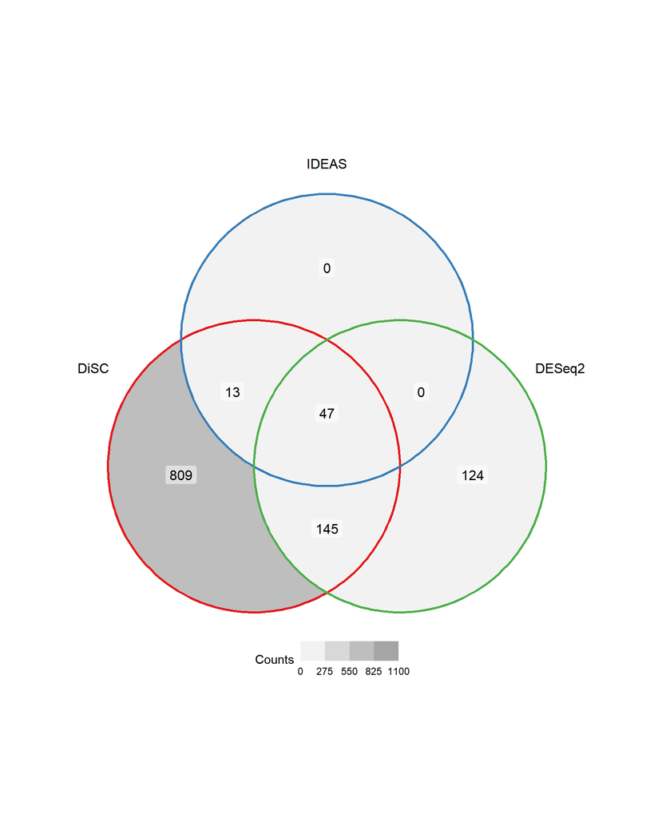

```r
Venn_break <- seq(from = 0,
                  to = ceiling(max(Venn_break$num_sig)/100)*100,
                  length.out = 5)
# cell_to_disp <- res %>%
#   group_by(Cell_Type) %>%
#   summarise(median_across_method = median(num_sig)) %>%
#   filter(median_across_method == max(median_across_method)) %>%
#   pull(Cell_Type) %>% as.character()
Venn_CD4 <- res %>%
  filter(Cell_Type == "CD4") %>%
  mutate(name_sig2 = str_split(name_sig, "::", simplify = FALSE)) %>%
  mutate(name_sig2 = magrittr::set_names(x = name_sig2, value = Method)) %>%
  pull(name_sig2)
Venn_CD4 <- Venn_CD4[base::match(competing_methods, names(Venn_CD4))] #df[match(target, df$name),]
figure2 <- ggVennDiagram(Venn_CD4, label = c("count")) +
  scale_color_brewer(palette = "Set1") +
  scale_fill_steps(high = "grey60", low = "grey100", breaks = Venn_break,
                   limits = c(min(Venn_break), max(Venn_break)),name = "Counts") +
  scale_x_continuous(expand = expansion(mult = .2))+
  theme(legend.position='bottom')
Venn_CD8 <- res %>%
  filter(Cell_Type == "CD8") %>%
  mutate(name_sig2 = str_split(name_sig, "::", simplify = FALSE)) %>%
  mutate(name_sig2 = magrittr::set_names(x = name_sig2, value = Method)) %>%
  pull(name_sig2)
Venn_CD8 <- Venn_CD8[base::match(competing_methods, names(Venn_CD8))] #df[match(target, df$name),]
figure3 <- ggVennDiagram(Venn_CD8, label = c("count")) +
  scale_color_brewer(palette = "Set1") +
  scale_fill_steps(high = "grey60", low = "grey100", breaks = Venn_break,
                   limits = c(min(Venn_break), max(Venn_break)),name = "Counts") +
  scale_x_continuous(expand = expansion(mult = .2))+
  theme(legend.position='bottom')
#the two figures will have the same legend as specified in
#breaks = Venn_break and limits = c(min(Venn_break), max(Venn_break))
#but it is still good to check this before align the plots
figure2
```

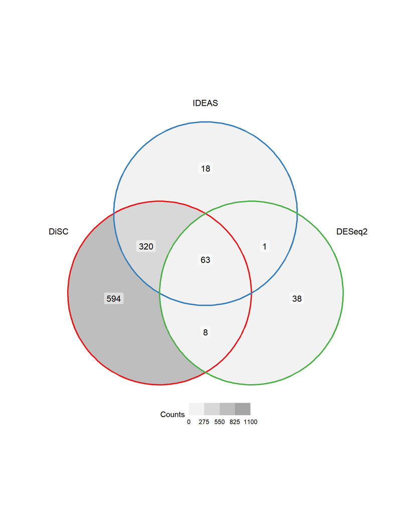

```r
figure3
```

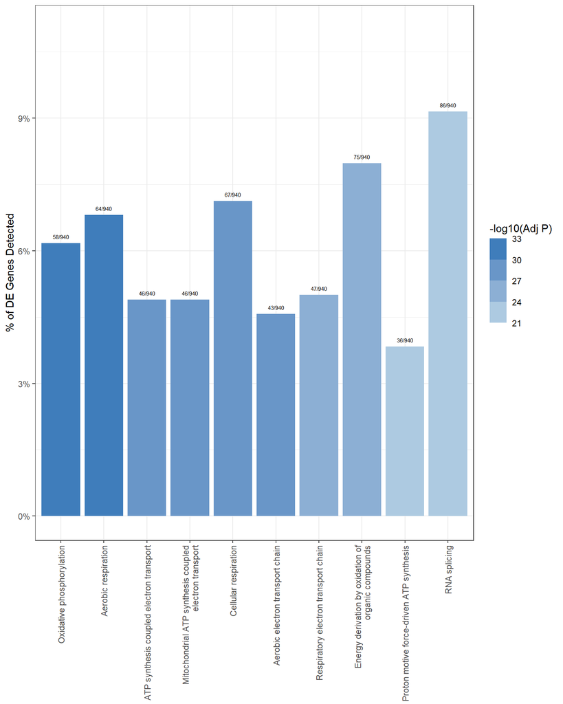

```r
figure2_3 <- lemon::grid_arrange_shared_legend(figure2, figure3,
                                               nrow = 1, position = "right") %>%
  as_ggplot()


# GO enrichment analysis
firstup <- function(x) {
  # uppercase the first letter in GO descriptions
  substr(x, 1, 1) <- toupper(substr(x, 1, 1))
  x
}
deg_CD4 <- res %>%
  filter(Cell_Type == "CD4", Method == "DiSC") %>%
  pull(name_sig) %>%
  str_split_1(pattern = "::")
deg_CD4_other_methods <- res %>%
  filter(Cell_Type == "CD4", Method != "DiSC") %>%
  pull(name_sig) %>%
  str_c(collapse = "::") %>%
  str_split_1(pattern = "::") %>%
  unique()
go_enrichment_CD4_BP <- enrichGO(gene = deg_CD4, OrgDb = "org.Hs.eg.db",
                                 keyType = "SYMBOL", ont = "BP")
go_enrichment_CD4_BP <- go_enrichment_CD4_BP %>%
  as_tibble() %>%
  mutate(Count_overlap = sapply(X = geneID,
                                FUN = \(x, g_vec){
                                  x = str_split_1(x, pattern = "/")
                                  return(sum(x %in% g_vec))},
                                simplify = TRUE, USE.NAMES =FALSE,
                                g_vec = deg_CD4_other_methods),
         Count_DiSC = Count - Count_overlap) %>%
  mutate(ratio = sapply(GeneRatio, function(txt) eval(parse(text=txt)),
                        simplify = TRUE)) %>%
  mutate(`-log_p` = -log10(p.adjust))
go_enrichment_CD4_BP_10 <-  go_enrichment_CD4_BP %>%
  slice_max(order_by = `-log_p`, n = 10) %>%
  mutate(Description = firstup(Description)) %>%
  mutate(Description = stringr::str_wrap(Description, width = 40))

deg_CD8 <- res %>%
  filter(Cell_Type == "CD8", Method == "DiSC") %>%
  pull(name_sig) %>%
  str_split_1(pattern = "::")
deg_CD8_other_methods <- res %>%
  filter(Cell_Type == "CD8", Method != "DiSC") %>%
  pull(name_sig) %>%
  str_c(collapse = "::") %>%
  str_split_1(pattern = "::") %>%
  unique()
go_enrichment_CD8_BP <- enrichGO(gene = deg_CD8, OrgDb = "org.Hs.eg.db",
                                 keyType = "SYMBOL", ont = "BP")
go_enrichment_CD8_BP <- go_enrichment_CD8_BP %>%
  as_tibble() %>%
  mutate(Count_overlap = sapply(X = geneID,
                                FUN = \(x, g_vec){
                                  x = str_split_1(x, pattern = "/")
                                  return(sum(x %in% g_vec))},
                                simplify = TRUE, USE.NAMES =FALSE,
                                g_vec = deg_CD8_other_methods),
         Count_DiSC = Count - Count_overlap) %>%
  mutate(ratio = sapply(GeneRatio, function(txt) eval(parse(text=txt)),
                        simplify = TRUE)) %>%
  mutate(`-log_p` = -log10(p.adjust))
go_enrichment_CD8_BP_10 <-  go_enrichment_CD8_BP %>%
  slice_max(order_by = `-log_p`, n = 10) %>%
  mutate(Description = firstup(Description)) %>%
  mutate(Description = stringr::str_wrap(Description, width = 40))

log_p_comb <- c(go_enrichment_CD4_BP_10$`-log_p`,
                go_enrichment_CD8_BP_10$`-log_p`)
go_breaks <- seq(from = floor(min(log_p_comb)), to = ceiling(max(log_p_comb)),
                 length.out = 5)
figure4 <- go_enrichment_CD4_BP_10 %>%
  mutate(Description = fct_reorder(Description, `-log_p`, .desc = TRUE)) %>%
  ggplot(aes(x = Description, y = ratio, fill = `-log_p`)) +
  geom_bar(stat = "identity")+
  geom_text(label = go_enrichment_CD4_BP_10$GeneRatio, vjust=-1, size = 2)+
  scale_y_continuous(labels = scales::percent, limits = c(0, 0.11)) +
  scale_fill_steps(name = "-log10(Adj P)", breaks = go_breaks,
                   limits = c(min(go_breaks), max(go_breaks)),
                   low = "#bdd7e7", high = "#2171b5")+
  theme_bw()+labs(x = NULL, y = "% of DE Genes Detected")+
  theme(axis.text.x = element_text(angle = 90, vjust = 0.5, hjust=1))
figure4
```

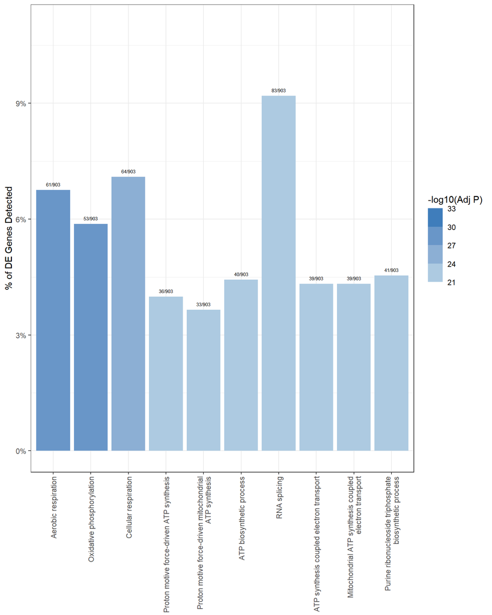

```r
figure5 <- go_enrichment_CD8_BP_10 %>%
  mutate(Description = fct_reorder(Description, `-log_p`, .desc = TRUE)) %>%
  ggplot(aes(x = Description, y = ratio, fill = `-log_p`)) +
  geom_bar(stat = "identity")+
  geom_text(label = go_enrichment_CD8_BP_10$GeneRatio, vjust=-1, size = 2)+
  scale_y_continuous(labels = scales::percent, limits = c(0, 0.11)) +
  scale_fill_steps(name = "-log10(Adj P)", breaks = go_breaks,
                   limits = c(min(go_breaks), max(go_breaks)),
                   low = "#bdd7e7", high = "#2171b5")+
  theme_bw()+labs(x = NULL, y = "% of DE Genes Detected")+
  theme(axis.text.x = element_text(angle = 90, vjust = 0.5, hjust=1))
figure5
```

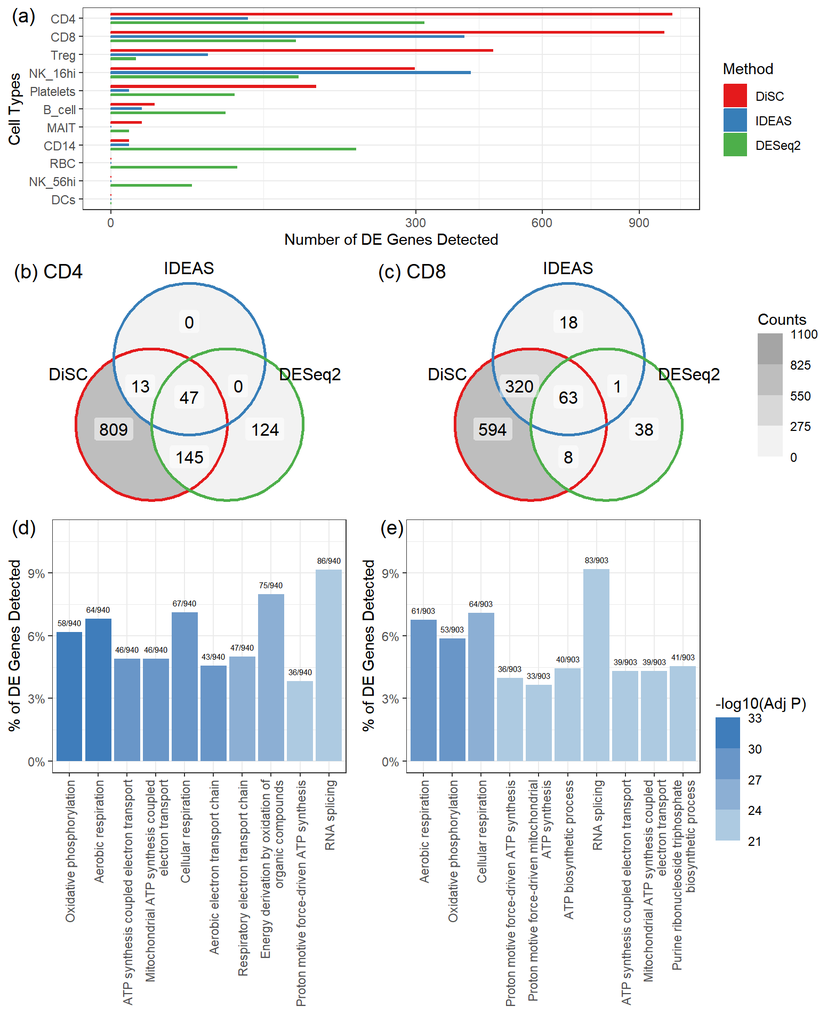

```r
figure4_5 <- lemon::grid_arrange_shared_legend(figure4, figure5,
                                               position = "right")%>%
  as_ggplot()

figures <-
  arrangeGrob(figure1,
              figure2_3,
              figure4_5,
              layout_matrix = rbind(c(1,1), c(2,2), c(3,3), c(3, 3))) %>%
  as_ggplot() +
  draw_plot_label(label = c("(a)", "(b) CD4", "(c) CD8", "(d)", "(e)"),
                  x = c(0, -0.025, 0.42, 0, 0.45),
                  y = c(1, 0.75, 0.75, 0.5, 0.5),
                  size = 14, color = "black",
                  fontface = "plain", family = NULL)
figures
```

```r
ggsave(filename = "results/covid_pbmc_anal.pdf" , figures,
       width = 8, height = 10)
ggsave(filename = "results/covid_pbmc_anal.jpeg" , figures,
       width = 8, height = 10)
```

# 4 References

- Zhang, M., et al. IDEAS: individual level differential expression analysis for single-cell RNA-seq data. Genome Biol 23, 33 (2022). https://doi.org/10.1186/s13059-022-02605-1.
- Velmeshev, D., et al. Single-cell genomics identifies cell type–specific molecular changes in autism. Science 364. 6441 (2019): 685-689.
- Stephenson, E., et al. Single-cell multi-omics analysis of the immune response in COVID-19. Nature medicine 27.5 (2021): 904-916.